# HW2

박찬영

2024-10-27

load required packages

```r
library(tidyverse)
library(nycflights13)
library(mdsr)
```

### Textbook 3.5.7 problem 3

How do delays vary over the course of the day? Illustrate your answer with a plot.

```r
glimpse(flights)
```

```
## Rows: 336,776
## Columns: 19
## $ year           <int> 2013, 2013, 2013, 2013, 2013, 2013, 2013, 2013, 2013, 2…
## $ month          <int> 1, 1, 1, 1, 1, 1, 1, 1, 1, 1, 1, 1, 1, 1, 1, 1, 1, 1, 1…
## $ day            <int> 1, 1, 1, 1, 1, 1, 1, 1, 1, 1, 1, 1, 1, 1, 1, 1, 1, 1, 1…
## $ dep_time       <int> 517, 533, 542, 544, 554, 554, 555, 557, 557, 558, 558, …
## $ sched_dep_time <int> 515, 529, 540, 545, 600, 558, 600, 600, 600, 600, 600, …
## $ dep_delay      <dbl> 2, 4, 2, -1, -6, -4, -5, -3, -3, -2, -2, -2, -2, -2, -1…
## $ arr_time       <int> 830, 850, 923, 1004, 812, 740, 913, 709, 838, 753, 849,…
## $ sched_arr_time <int> 819, 830, 850, 1022, 837, 728, 854, 723, 846, 745, 851,…
## $ arr_delay      <dbl> 11, 20, 33, -18, -25, 12, 19, -14, -8, 8, -2, -3, 7, -1…
## $ carrier        <chr> "UA", "UA", "AA", "B6", "DL", "UA", "B6", "EV", "B6", "…
## $ flight         <int> 1545, 1714, 1141, 725, 461, 1696, 507, 5708, 79, 301, 4…
## $ tailnum        <chr> "N14228", "N24211", "N619AA", "N804JB", "N668DN", "N394…
## $ origin         <chr> "EWR", "LGA", "JFK", "JFK", "LGA", "EWR", "EWR", "LGA",…
## $ dest           <chr> "IAH", "IAH", "MIA", "BQN", "ATL", "ORD", "FLL", "IAD",…
## $ air_time       <dbl> 227, 227, 160, 183, 116, 150, 158, 53, 140, 138, 149, 1…
## $ distance       <dbl> 1400, 1416, 1089, 1576, 762, 719, 1065, 229, 944, 733, …
## $ hour           <dbl> 5, 5, 5, 5, 6, 5, 6, 6, 6, 6, 6, 6, 6, 6, 6, 5, 6, 6, 6…
## $ minute         <dbl> 15, 29, 40, 45, 0, 58, 0, 0, 0, 0, 0, 0, 0, 0, 0, 59, 0…
## $ time_hour      <dttm> 2013-01-01 05:00:00, 2013-01-01 05:00:00, 2013-01-01 0…
```

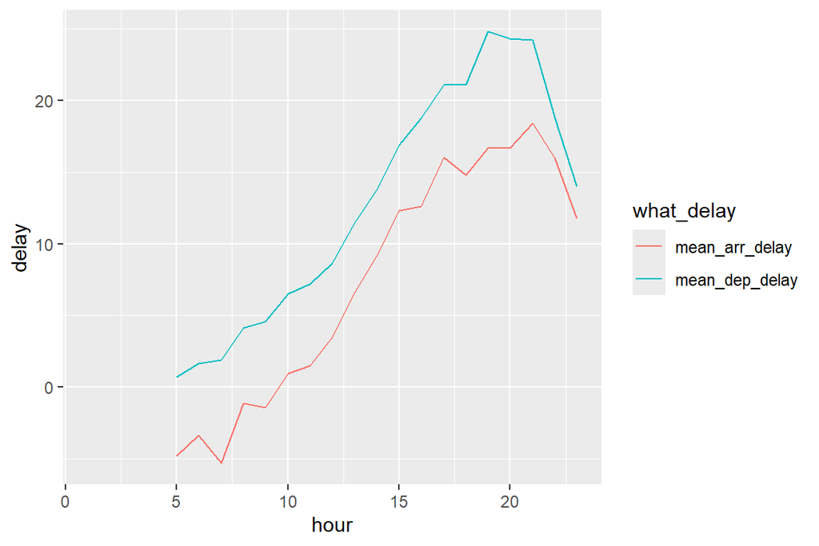

```r
#출발시간에 따른 평균 지연시간을 계산하자
hour_delay <- flights %>%
  summarise(
    mean_dep_delay = mean(dep_delay, na.rm = TRUE),
    mean_arr_delay = mean(arr_delay, na.rm = TRUE),
    .by = hour
  )
hour_delay %>%
  pivot_longer(
    cols = c("mean_dep_delay", "mean_arr_delay"),
    names_to = "what_delay",
    values_to = "delay"
  ) %>%
  ggplot(aes(x = hour, y = delay)) +
  geom_line(aes(color = what_delay))
```

```r
#19~21시에 도착 지연과 출발 지연이 모두 높아진다.
```

### Textbook 4.6 problem 1

Restyle the following pipelines

```r
flights|>filter(dest=="IAH")|>group_by(year,month,day)|>summarize(n=n(),
delay=mean(arr_delay,na.rm=TRUE))|>filter(n>10)

flights|>filter(carrier=="UA",dest%in%c("IAH","HOU"),sched_dep_time>
0900,sched_arr_time<2000)|>group_by(flight)|>summarize(delay=mean(
arr_delay,na.rm=TRUE),cancelled=sum(is.na(arr_delay)),n=n())|>filter(n>10)
```

다음은 수정한 코드이다. (실행하진 않는다)

```r
flights |>
  filter(dest == "IAH") |>
  group_by(year, month, day) |>
  summarize(
    n = n(),
    delay = mean(arr_delay, na.rm = TRUE)
  ) |>
  filter(n > 10)

flights |>
  filter(
    carrier == "UA",
    dest %in% c("IAH", "HOU"),
    sched_dep_time > 0900,
    sched_arr_time < 2000
  ) |>
  group_by(flight) |>
  summarize(
    delay = mean(arr_delay, na.rm = TRUE),
    cancelled = sum(is.na(arr_delay)),
    n = n()
  ) |>
  filter(n > 10)
```

### Textbook 9.2.1 problem 1

Create a scatterplot of `hwy` vs. `displ` where the points are pink filled in triangles.

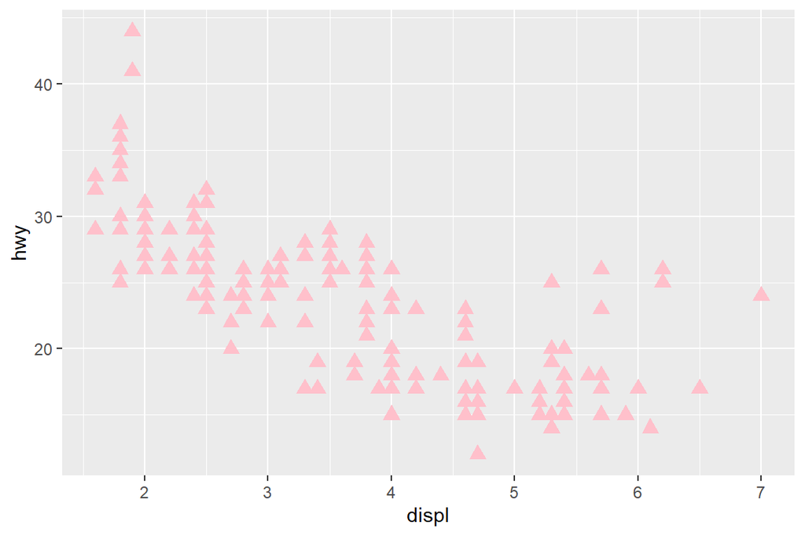

```r
ggplot(mpg) +
  geom_point(aes(x = displ, y = hwy), color = "pink", shape = 17, size = 3)
```

### Textbook 9.2.1 problem 4

What happens if you map an aesthetic to something other than a variable name, like `aes(color = displ < 5)`?

Note, you’ll also need to specify x and y.

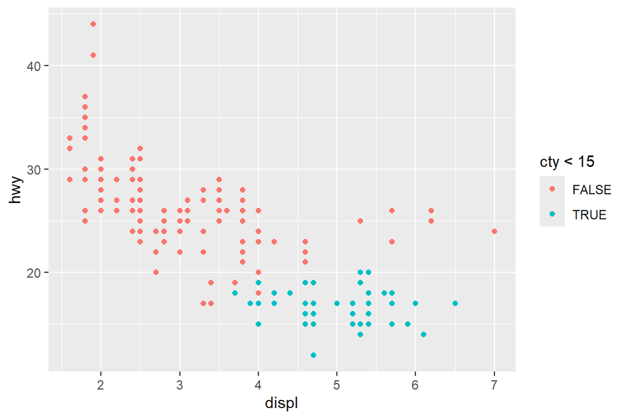

```r
ggplot(mpg) +
  geom_point(aes(x = displ, y = hwy, color = cty < 15))
```

```r
#color 매핑에 조건문을 넣으면 TRUE와 FALSE를 그룹지어서 색을 입혀준다.
#shape에 대해서도 비슷할 것이다.
```

### Textbook 9.3.1 problem 4

Recreate the R code necessary to generate the following graphs.

Note that wherever a categorical variable is used in the plot, it’s `drv.`

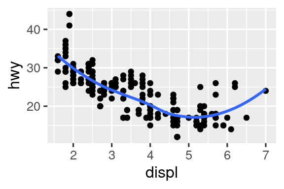

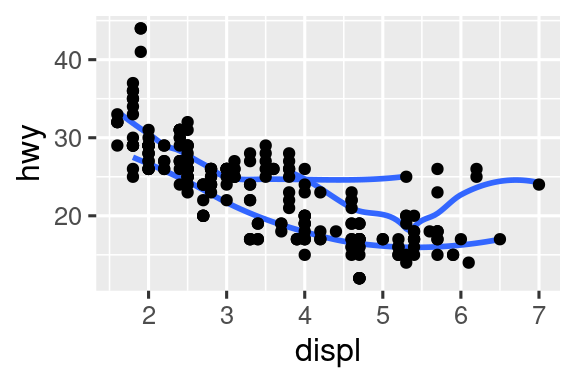

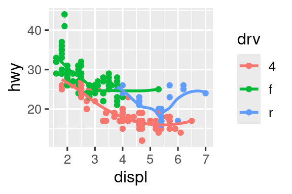

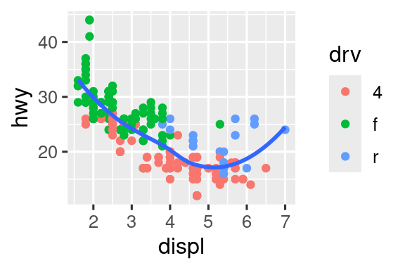

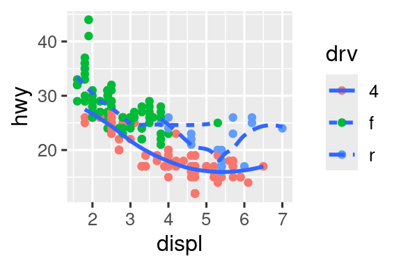

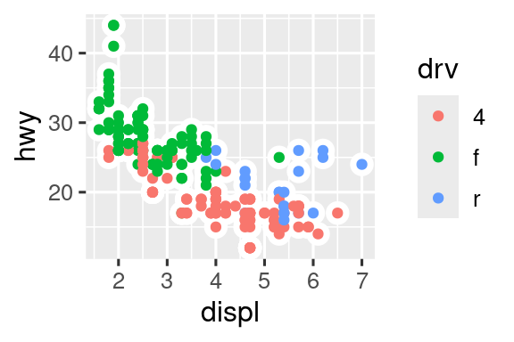

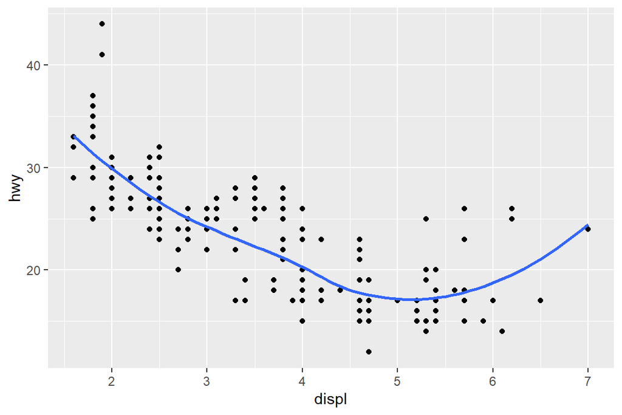

```r
displ_hwy <- ggplot(mpg, aes(displ, hwy)) +
  geom_point()

#1
displ_hwy +
  geom_smooth(se = FALSE)
```

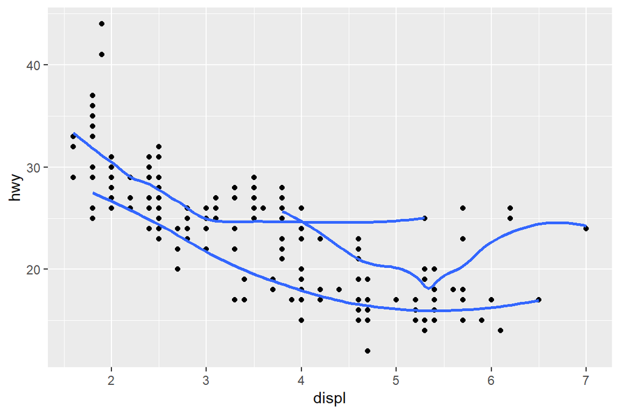

```r
#2
displ_hwy +
  geom_smooth(aes(group = drv), se = FALSE)
```

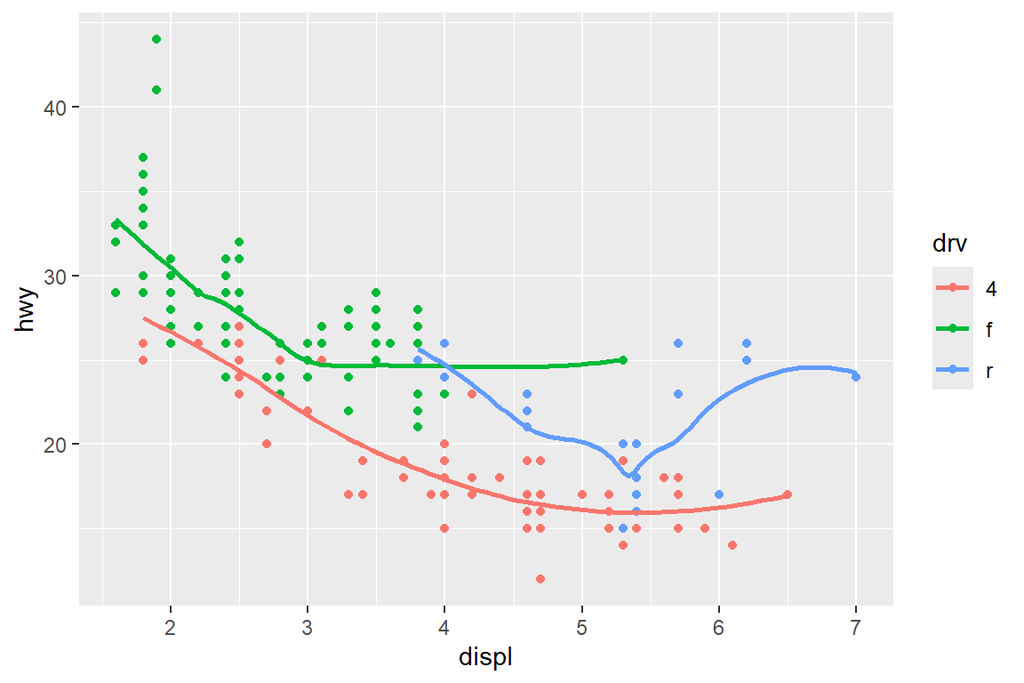

```r
#3
displ_hwy +
  geom_point(aes(color = drv)) +
  geom_smooth(aes(color = drv), se = FALSE)
```

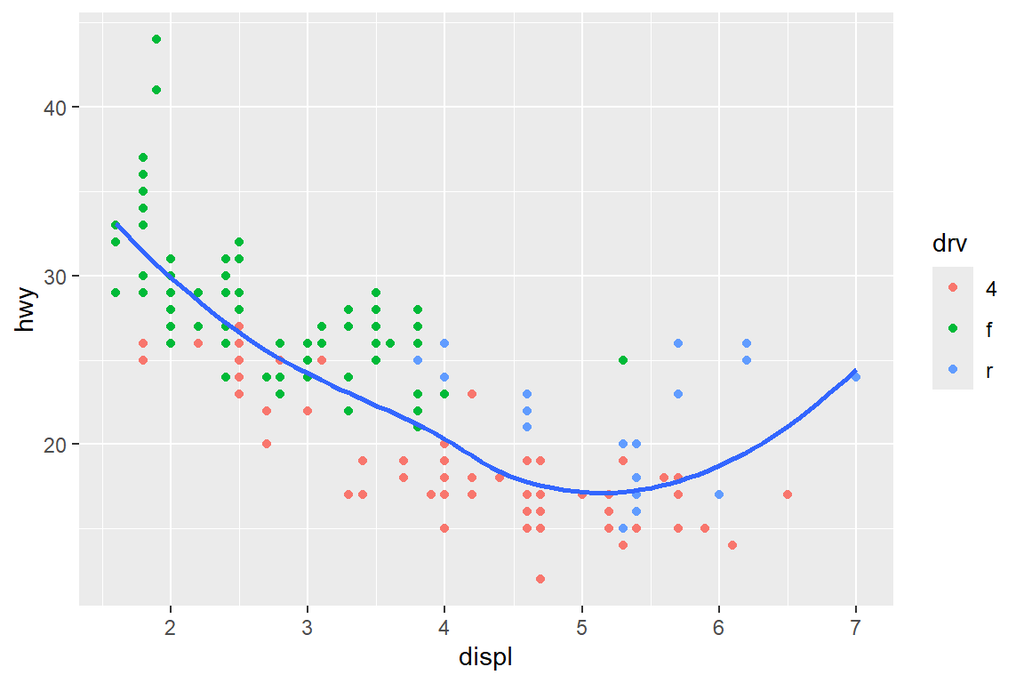

```r
#4
displ_hwy +
  geom_point(aes(color = drv)) +
  geom_smooth(se = FALSE)
```

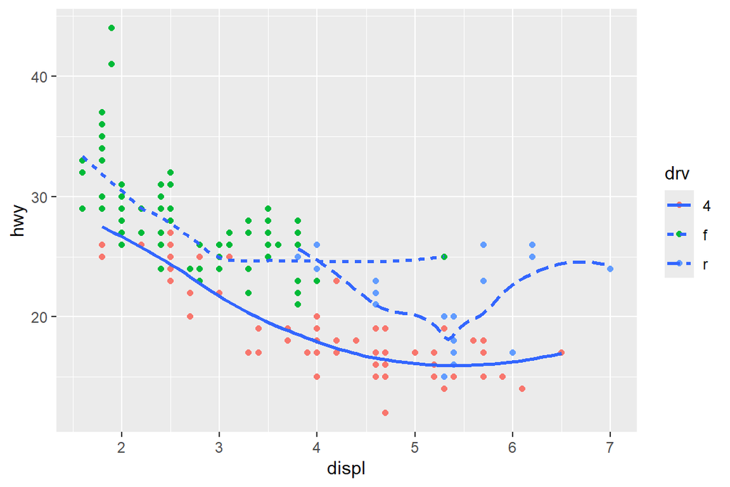

```r
#5
displ_hwy +
  geom_point(aes(color = drv)) +
  geom_smooth(aes(linetype = drv), se = FALSE)
```

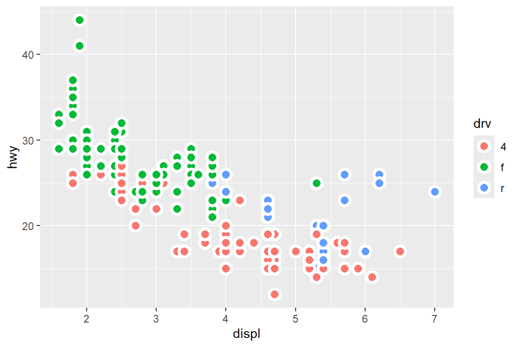

```r
#6
displ_hwy +
  geom_point(aes(fill = drv), size = 3, shape = 21, stroke = 2, color = "white")
```